# R Notebook following ModernStatisticswithR.com

## Exercise

The following tasks all involve checking conditions for the airquality data: 1. Which was the coldest day during the period?

```r
which.min(airquality$Temp)
```

```
[1] 5
```

```r
# day 5
```

2. How many days was the wind speed greater than 17 mph?

```r
sum(airquality$Wind > 17)
```

```
[1] 3
```

```r
# 3 days
```

3. How many missing values are there in the Ozone vector?

```r
sum(is.na(airquality$Ozone))
```

```
[1] 37
```

```r
# 37 missing values
```

4. How many days are there where the temperature was below 70 and the wind speed was above 10?

```r
sum(airquality$Temp < 70 & airquality$Wind > 10)
```

```
[1] 22
```

```r
# 22 days
```

5. The function `cut` can be used to create a categorical variable from a numerical variable, by dividing it into categories corresponding to different intervals. Read its documentation and then create a new categorical variable in the `airquality` data, `TempCat`, which divides `Temp` into three intervals `(50, 70]`, `(70, 90]`, `(90, 110]`.

```r
airquality$TempCat <- cut(airquality$Temp,
                          breaks = c(50, 70, 90, 110))
airquality
```

| Ozone | Solar.R | Wind | Temp | Month | Day | TempCat |
| --- | --- | --- | --- | --- | --- | --- |
| 41 | 190 | 7.4 | 67 | 5 | 1 | (50,70] |
| 36 | 118 | 8.0 | 72 | 5 | 2 | (70,90] |
| 12 | 149 | 12.6 | 74 | 5 | 3 | (70,90] |
| 18 | 313 | 11.5 | 62 | 5 | 4 | (50,70] |
| NA | NA | 14.3 | 56 | 5 | 5 | (50,70] |
| 28 | NA | 14.9 | 66 | 5 | 6 | (50,70] |
| 23 | 299 | 8.6 | 65 | 5 | 7 | (50,70] |
| 19 | 99 | 13.8 | 59 | 5 | 8 | (50,70] |
| 8 | 19 | 20.1 | 61 | 5 | 9 | (50,70] |
| NA | 194 | 8.6 | 69 | 5 | 10 | (50,70] |

[output cut: 143 more lines]

- the `aggregate()` function is used to create grouped summaries of the data

```r
aggregate(Temp ~ Month, data = airquality, FUN = mean) # `FUN` is which function we are using to compute the data with; here it is mean
```

| Month | Temp |
| --- | --- |
| 5 | 65.54839 |
| 6 | 79.10000 |
| 7 | 83.90323 |
| 8 | 83.96774 |
| 9 | 76.90000 |

```r
aggregate(cbind(Temp, Wind) ~ Month, data = airquality, FUN = sd) # here we are computing standard deviation
```

| Month | Temp | Wind |
| --- | --- | --- |
| 5 | 6.854870 | 3.531450 |
| 6 | 6.598589 | 3.769234 |
| 7 | 4.315513 | 3.035981 |
| 8 | 6.585256 | 3.225930 |
| 9 | 8.355671 | 3.461254 |

- using `length` for `FUN`, we can see how many observations are in the group; aka how many months days are being returned for each month for the below example (it returns the length of the vector that is created with the aggregate function)

```r
aggregate(Temp ~ Month, data = airquality, FUN = length)
```

| Month | Temp |
| --- | --- |
| 5 | 31 |
| 6 | 30 |
| 7 | 31 |
| 8 | 31 |
| 9 | 30 |

- another function that is used for group summaries is `by` which just makes the output nicer

```r
by(airquality$Temp, airquality$Month, mean)
```

```
airquality$Month: 5
[1] 65.54839
---------------------------------------------------------------------------------------------
airquality$Month: 6
[1] 79.1
---------------------------------------------------------------------------------------------
airquality$Month: 7
[1] 83.90323
---------------------------------------------------------------------------------------------
airquality$Month: 8
[1] 83.96774
---------------------------------------------------------------------------------------------
airquality$Month: 9
[1] 76.9
```

- it works better than aggregate for functions that want to take more than one variable

```r
names(airquality) # to check which columns the Wind (3) and Temp (4) are
```

```
[1] "Ozone"   "Solar.R" "Wind"    "Temp"    "Month"   "Day"     "TempCat"
```

```r
by(airquality[ , 3:4], airquality$Month, cor)
```

```
airquality$Month: 5
          Wind      Temp
Wind  1.000000 -0.373276
Temp -0.373276  1.000000
---------------------------------------------------------------------------------------------
airquality$Month: 6
           Wind       Temp
Wind  1.0000000 -0.1210353
Temp -0.1210353  1.0000000
---------------------------------------------------------------------------------------------
airquality$Month: 7
           Wind       Temp
Wind  1.0000000 -0.3052355
Temp -0.3052355  1.0000000
---------------------------------------------------------------------------------------------
airquality$Month: 8
           Wind       Temp
Wind  1.0000000 -0.5076146
Temp -0.5076146  1.0000000
---------------------------------------------------------------------------------------------
airquality$Month: 9
           Wind       Temp
Wind  1.0000000 -0.5704701
Temp -0.5704701  1.0000000
```

## Exercise

```r
install.packages('datasauRus')
library(datasauRus)
?datasaurus_dozen
```

```r
mean(datasaurus_dozen$x)
```

```
[1] 54.2657
```

```r
mean(datasaurus_dozen$y)
```

```
[1] 47.8351
```

```r
sd(datasaurus_dozen$y)
```

```
[1] 26.84777
```

```r
by(datasaurus_dozen[ , 2:3], datasaurus_dozen$dataset, cor)
```

```
datasaurus_dozen$dataset: away
            x           y
x  1.00000000 -0.06412835
y -0.06412835  1.00000000
---------------------------------------------------------------------------------------------
datasaurus_dozen$dataset: bullseye
            x           y
x  1.00000000 -0.06858639
y -0.06858639  1.00000000
---------------------------------------------------------------------------------------------
datasaurus_dozen$dataset: circle
            x           y
x  1.00000000 -0.06834336
y -0.06834336  1.00000000
---------------------------------------------------------------------------------------------
datasaurus_dozen$dataset: dino
            x           y
x  1.00000000 -0.06447185
y -0.06447185  1.00000000
---------------------------------------------------------------------------------------------
datasaurus_dozen$dataset: dots
            x           y
x  1.00000000 -0.06034144
y -0.06034144  1.00000000
---------------------------------------------------------------------------------------------
datasaurus_dozen$dataset: h_lines
            x           y
x  1.00000000 -0.06171484
y -0.06171484  1.00000000
---------------------------------------------------------------------------------------------
datasaurus_dozen$dataset: high_lines
            x           y
x  1.00000000 -0.06850422
y -0.06850422  1.00000000
---------------------------------------------------------------------------------------------
datasaurus_dozen$dataset: slant_down
            x           y
x  1.00000000 -0.06897974
y -0.06897974  1.00000000
---------------------------------------------------------------------------------------------
```

[output cut: 9 more lines]

```
---------------------------------------------------------------------------------------------
datasaurus_dozen$dataset: v_lines
            x           y
x  1.00000000 -0.06944557
y -0.06944557  1.00000000
---------------------------------------------------------------------------------------------
datasaurus_dozen$dataset: wide_lines
            x           y
x  1.00000000 -0.06657523
y -0.06657523  1.00000000
---------------------------------------------------------------------------------------------
datasaurus_dozen$dataset: x_shape
            x           y
x  1.00000000 -0.06558334
y -0.06558334  1.00000000
```

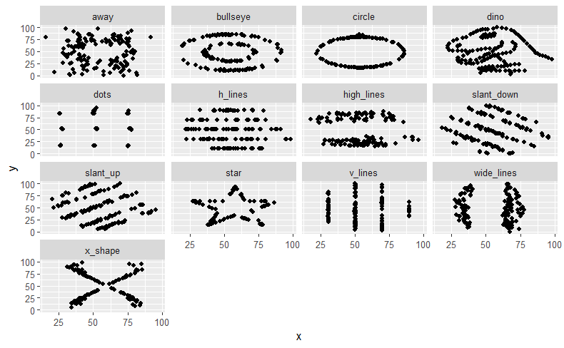

```r
ggplot(datasaurus_dozen, aes(x, y)) +
  geom_point() +
  facet_wrap(~dataset)
```

- pipes (`|>`) are a way to combine multiple aspects of a code

```r
install.packages("dplyr")
library(dplyr)
# old way of writing code:
# new_variable <- function_2(function_1(your_data))

# new way with piping
# your_data |> function_1() |> function_2() -> new_variable
```

- the is the way we just learned to find the grouped means

```r
# Extract hot days:
airquality2 <- filter(airquality, Temp > 80)
# Convert wind speed to m/s:
airquality2 <- mutate(airquality, Wind = Wind * 0.44704)
# Compute mean wind speed for each month:
airquality <- group_by(airquality, Month)
hot_wind_means <- summarise(airquality, Mean_wind_speed = mean(Wind))

hot_wind_means
```

| Month | Mean_wind_speed |
| --- | --- |
| 5 | 11.622581 |
| 6 | 10.266667 |
| 7 | 8.941935 |
| 8 | 8.793548 |
| 9 | 10.180000 |

- but with piping, we can make it a lot quicker:

```r
airquality |>
      filter(Temp > 80) |>
      mutate(Wind = Wind * 0.44704) |>
      group_by(Month) |>
      summarise(Mean_wind_speed = mean(Wind)) ->
      hot_wind_means

hot_wind_means
```

| Month | Mean_wind_speed |
| --- | --- |
| 5 | 6.660896 |
| 6 | 4.282643 |
| 7 | 3.858913 |
| 8 | 3.444443 |
| 9 | 3.750169 |

## Exercise

Using the bookstore data: age <- c(28, 48, 47, 71, 22, 80, 48, 30, 31) purchase <- c(20, 59, 2, 12, 22, 160, 34, 34, 29) visit_length <- c(5, 2, 20, 22, 12, 31, 9, 10, 11) bookstore <- data.frame(age, purchase, visit_length) 1. Add a new variable rev_per_minute which is the ratio between purchase and the visit length, using a pipe and a function from dplyr.

```r
age <- c(28, 48, 47, 71, 22, 80, 48, 30, 31)
purchase <- c(20, 59, 2, 12, 22, 160, 34, 34, 29)
visit_length <- c(5, 2, 20, 22, 12, 31, 9, 10, 11)
bookstore <- data.frame(age, purchase, visit_length)

library(magrittr)

bookstore |> mutate(rev_per_minute = purchase/visit_length) -> bookstore

bookstore
```

| age | purchase | visit_length | rev_per_minute |
| --- | --- | --- | --- |
| 28 | 20 | 5 | 4.0000000 |
| 48 | 59 | 2 | 29.5000000 |
| 47 | 2 | 20 | 0.1000000 |
| 71 | 12 | 22 | 0.5454545 |
| 22 | 22 | 12 | 1.8333333 |
| 80 | 160 | 31 | 5.1612903 |
| 48 | 34 | 9 | 3.7777778 |
| 30 | 34 | 10 | 3.4000000 |
| 31 | 29 | 11 | 2.6363636 |

- adding the `with` function to pipping helps with certain functions where the right hand of it doesn’t agree with the output of the left hand of it

```r
library(ggplot2)
# this won't work:
# msleep |> cor(sleep_total, sleep_rem, use = "complete.obs")

# this will work:
msleep |> with(cor(sleep_total, sleep_rem, use = "complete.obs"))
```

```
[1] 0.751755
```

- also if we need to include a placeholder, you can add `_` as one:

```r
airquality |>
  aggregate(Temp ~ Month,
            data = _,
            FUN = mean)
```

| Month | Temp |
| --- | --- |
| 5 | 65.54839 |
| 6 | 79.10000 |
| 7 | 83.90323 |
| 8 | 83.96774 |
| 9 | 76.90000 |

- to read in csv or data files in general:

```r
# imported_data <- read.csv("data_file.csv")

# to have a popup open to select which data you want to use:
# imported_data2 <- read.csv(file.choose())
```

# 3. The cornerstones of statistics

- three main schools in statistical modeling:
  - **frequentist** - uses frequency (long-run proportion) of an event to describe the probability it occurs
    - traditionally using p-values and confidence intervals
    - more objective approach
    - suitable for analyzing experiments
  - **Bayesian** - incorportates prior knowledge and personal beliefs about the event occuring
    - more flexible and incorporates prior knowledge and can be updated when new evidence is available
  - **machine learning** - focused on developing algorithms and computational tools for automatically idenfiying patterns in data then making predictions on those patterns
    - only care about if they are good at predicting test datasets
- tools used for all 3 are *frequency tables* and *contingency tables*

```r
library(palmerpenguins)
# we want to see the frequency (amount of times) each value occurs in the data
# so lets take a look at species of penguins

table(penguins$species) # without pipes
```

```
   Adelie Chinstrap    Gentoo
      152        68       124
```

```r
library(dplyr)
penguins |> select(species) |> table() # with pipes
```

```
species
   Adelie Chinstrap    Gentoo
      152        68       124
```

- but we will eventually want to publish the findings so we need to update the aesthetics for the table

```r
# install the additional packages:
install.packages(c("gtsummary", "flextable", "ivo.table"))
```

```r
library(gtsummary)
library(dplyr)

tbl_summary(penguins[, "species"]) # without pipes
```

[output not shown]

| **Characteristic** | **N = 344**<sup>1</sup> |
| --- | --- |
| species |  |
| Adelie | 152 (44%) |
| Chinstrap | 68 (20%) |
| Gentoo | 124 (36%) |

<sup>1</sup> n (%)

```r
install.packages("dplyr")
install.packages(c("gtsummary", "flextable", "ivo.table"))
penguins |>
  select(species) |>
  tbl_summary()
```

| **Characteristic** | **N = 344**<sup>1</sup> |
| --- | --- |
| species |  |
| Adelie | 152 (44%) |
| Chinstrap | 68 (20%) |
| Gentoo | 124 (36%) |

<sup>1</sup> n (%)

- and here is how we can export the table:

```r
library(flextable)
penguins |>
  select(species) |>
  tbl_summary() |>
  as_flex_table() |> # Convert the table to a format that can be exported
  save_as_docx(path = "sample_my_table.docx")
```

- and here is how to construct tables using the `ivo.table` package:

```r
library(ivo.table)
ivo_table(penguins[,"species"]) # without pipes
```

| species Adelie | species Chinstrap | species Gentoo |
| --- | --- | --- |
| 152 | 68 | 124 |

```r
library(dplyr)
library(ivo.table)
penguins |>
  select(species) |>
  ivo_table()
```

| species Adelie | species Chinstrap | species Gentoo |
| --- | --- | --- |
| 152 | 68 | 124 |

- and the table that results is editable for colors and fonts

```r
penguins |>
  select(species) |>
  ivo_table(color = "darkred",
            font = "Garamond",
            percent_by = "row")
```

| species Adelie | species Chinstrap | species Gentoo |
| --- | --- | --- |
| 44,2 % | 19,8 % | 36,0 % |

- or can have long format tables

```r
penguins |>
  select(species) |>
  ivo_table(long_table = TRUE)
```

| species | Count |
| --- | --- |
| Adelie | 152 |
| Chinstrap | 68 |
| Gentoo | 124 |

- and these can also be saved as documents:

```r
library(flextable)
penguins |>
  select(species) |>
  ivo_table() |>
  save_as_docx(path = "sample_my_table2.docx")
```

- **contingency tables** (cross-tabulations/cross-tables) - summarise the relationship between two or more variables

```r
ftable(penguins$species,
       penguins$island) # without pipes
```

```
           Biscoe Dream Torgersen

Adelie         44    56        52
Chinstrap       0    68         0
Gentoo        124     0         0
```

```r
penguins |>
  select(species, island) |>
  ftable()
```

```
          island Biscoe Dream Torgersen
species
Adelie               44    56        52
Chinstrap             0    68         0
Gentoo              124     0         0
```

- to make these tables more aesthetically pleasing you can use the ivo_table, highlight specific values (and save it)

```r
library(ivo.table)
penguins |> select(species, island) |>
  ivo_table(color = "darkred",
            font = "Garamond",
            percent_by = "tot",
            highlight_cols = 2,
            highlight_rows = 3) |>
  save_as_docx(path = "penguins.docx")

penguins |> select(species, island) |>
  ivo_table(color = "darkred",
            font = "Garamond",
            percent_by = "tot",
            highlight_cols = 2,
            highlight_rows = 3)
```

| island | species Adelie | species Chinstrap | species Gentoo |
| --- | --- | --- | --- |
| Biscoe | 12,8 % | 0,0 % | 36,0 % |
| Dream | 16,3 % | 19,8 % | 0,0 % |
| Torgersen | 15,1 % | 0,0 % | 0,0 % |

- there is also a way to do this with `tbl_summary`

```r
library(gtsummary)
tbl_summary(penguins[,c("species",
                        "island")],
            by = species) # without pipes
```

| **Characteristic** | **Adelie** N = 152<sup>1</sup> | **Chinstrap** N = 68<sup>1</sup> | **Gentoo** N = 124<sup>1</sup> |
| --- | --- | --- | --- |
| island |  |  |  |
| Biscoe | 44 (29%) | 0 (0%) | 124 (100%) |
| Dream | 56 (37%) | 68 (100%) | 0 (0%) |
| Torgersen | 52 (34%) | 0 (0%) | 0 (0%) |

<sup>1</sup> n (%)

```r
library(dplyr)
library(gtsummary)
penguins |>
  select(species, island) |>
  tbl_summary(by = species)
```

| **Characteristic** | **Adelie** N = 152<sup>1</sup> | **Chinstrap** N = 68<sup>1</sup> | **Gentoo** N = 124<sup>1</sup> |
| --- | --- | --- | --- |
| island |  |  |  |
| Biscoe | 44 (29%) | 0 (0%) | 124 (100%) |
| Dream | 56 (37%) | 68 (100%) | 0 (0%) |
| Torgersen | 52 (34%) | 0 (0%) | 0 (0%) |

<sup>1</sup> n (%)

# 4. Exploratory Data Analysis and Unsupervised Learning

# 5. Dealing with messy data

# 6. R programming

# 7. The role of simulation in modern statistics

# 8. Regression models

# 9. Survival analysis and censored data

# 10. Structural equation models

# 11. Predictive modeling and machine learning

# 12. Advanced topics

# 13. Debugging

# 14. Mathematical appendix